# Rendimentos das Famílias Maranhenses

Uma análise da Pesquisa de Orçamentos Familiares - POF (2017-2018)

Observatório do Mercado de Trabalho do Maranhão (OMT-MA

29/10/2019

# 1 Sobre a Pesquisa

A Pesquisa de Orçamentos Familiares - POF é uma pesquisa domiciliar, realizada por amostragem e que busca:

> “Obter informações sobre a **estrutura de orçamentos** (aquisições de produtos, serviços e rendimentos), **estado nutricional e condições de vida** das famílias e população brasileira.”

> (IBGE, 2017)

A pesquisa foi realizada em domicílios particulares localizados nas áreas urbanas e rurais de todas as Unidades da Federação (UF) e contou com uma amostra de cerca de 75.000 domicílios. Como a pesquisa foi realizada durante **12 meses**, além de identificar aquisições realizadas continuamente pelas famílias, durante todo o ano, também identificou as aquisições sazonais.

Para a realização deste artigo, foram utilizados dados apenas de **Distribuição e Rendimento total e variação patrimonial médio mensal familiar, por classes de rendimento total e variação patrimonial mensal familiar, segundo os tipos de origem do rendimento, com indicação do número e tamanho médio das famílias - Maranhão - período 2017-2018.**

## 1.1 Conceitos

- **Rendimento total e variação patrimonial =** Rendimento total **+** Variação patrimonial
  - **Rendimento total =** Rendimento do trabalho **+** Transferência **+** Rendimento de aluguel **+** Rendimento não monetário
    - **Rendimento do trabalho =** Empregado **+** Empregador **+** Conta própria
      - **Empregador:** Pessoa que trabalhava explorando o seu próprio empreendimento, tendo pelo menos um empregado e contando, ou não, com a ajuda de trabalhador não remunerado.
      - **Conta própria:** Pessoa que trabalhava explorando o seu próprio empreendimento, sozinha ou com sócio, sem ter empregado e contando, ou não, com a ajuda de trabalhador não remunerado.
    - **Transferência =** Aposentadoria e pensão do INSS **+** Aposentadoria, pensão da previdência pública **+** Aposentadoria, pensão da previdência privada **+** Programas sociais federais **+** Pensão alimentícia, mesada ou doação **+** Outras transferências.

# 2 Famílias

No estado, existiam **1.974.466 famílias**. Dessas, 44,89% ganhavam até 1908 reais, os que ganhavam mais de 1908 a 2862 reais totalizavam 23,62%, por outro lado, os que ganhavam entre mais de 2862 a 5724 reais representavam 22.54% das famílias maranhenses, assim, essas três primeiras classes de rendimentos totalizavam 91,05% das famílias do Maranhão.

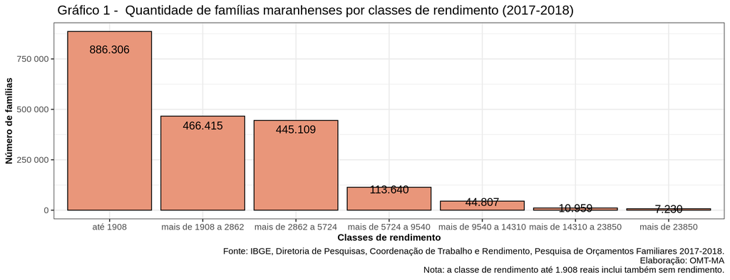

Uma família maranhense possui, em média, **3,54 pessoas**. Analisando o tamanho médio da família maranhense por classes de rendimento, observa-se que as famílias maranhenses das classes de rendimento intermediárias são as que possuem, em média, maior quantidade de membros. Por outro lado, as famílias da classe de rendimento que ganham mais de 23.850 reais possuem a menor média de pessoas por grupo familiar, apenas 2,79 pessoas.

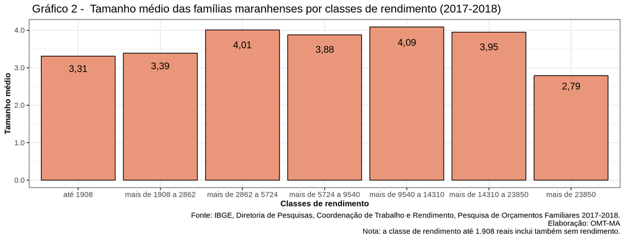